# Data Visualization Solutions

## 3.7.1 Statistical Transformations Exercises

1. What is the default geom associated with stat_summary()? How could you rewrite the previous plot to use that geom function instead of the stat function?

The default geom associated with `stat_summary()` is `pointrange`. The previous plot given in the textbook can be recreated by changing `stat_summary()` to `geom_pointrange()` and adding `stat = "summary"` because the default stat for `geom_pointrange()` is identity.

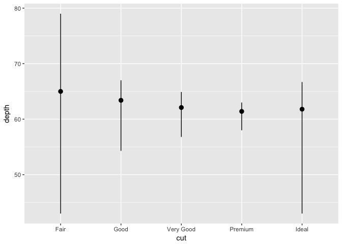

```r
ggplot(data = diamonds) +
  geom_pointrange(
    mapping = aes(x = cut, y = depth),
    stat = "summary",
    fun.ymin = min,
    fun.ymax = max,
    fun.y = median
  )
```

2. What does geom_col() do? How is it different to geom_bar()?

Both `geom_col()` and `geom_bar()`create bar charts. `geom_bar()` has `stat_count` by default so it sets bar heights proportional to number of cases per group. `geom_col()` has `stat_identity` so it sets bar heights to data as is.

3. Most geoms and stats come in pairs that are almost always used in concert. Read through the documentation and make a list of all the pairs. What do they have in common?

Here are the pairs for the most common geoms I use: - geom_bar : stat_count - geom_point : stat_identity - geom_histogram : stat_bin - geom_area : stat_identity - geom_boxplot : stat_boxplot - geom_density : stat_density

4. What variables does stat_smooth() compute? What parameters control its behaviour?

You can find this answer in the Computed Variables of the `stat_smooth` documentation. It computes: predicted value, lower pointwise confidence interval around the mean, upper pointwise confidence interval around the mean, and standard error.

Two important parameters worth mentioning are `se` to display a confidence interval or not and `method` for the choice of modeling functiong (such as a linear model).

5. In our proportion bar chart, we need to set group = 1. Why? In other words what is the problem with these two graphs?

The problem is that it is calculating the proportion for each group instead of between groups. The plots on the right give the intended fix.

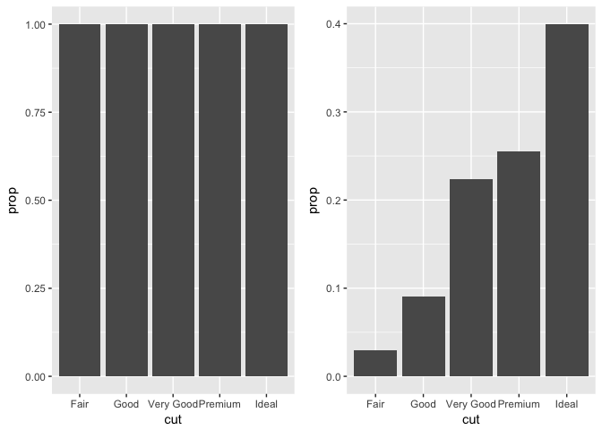

```r
# original
p1 <- ggplot(data = diamonds) +
    geom_bar(mapping = aes(x = cut, y = ..prop..))
# add group = 1
p2 <- ggplot(data = diamonds) +
    geom_bar(mapping = aes(x = cut, y = ..prop.., group = 1))
grid.arrange(p1, p2, ncol = 2)
```

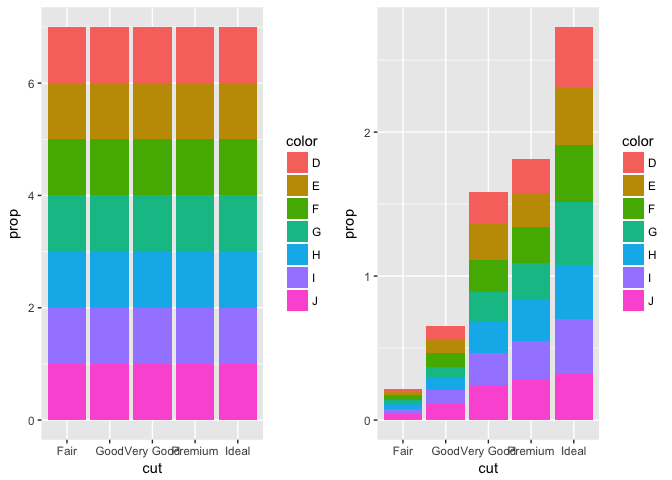

```r
# original
p1 <- ggplot(data = diamonds) +
    geom_bar(mapping = aes(x = cut, fill = color, y = ..prop..))
# add group = color
p2 <- ggplot(data = diamonds) +
    geom_bar(mapping = aes(x = cut, fill = color, y = ..prop.., group = color))
grid.arrange(p1, p2, ncol = 2)
```

## 3.8.1 Position Adjustments Exercises

1. What is the problem with this plot? How could you improve it?

There’s overplotting in the left hand plot because points have the same values. You can fix it by adding some jitter by changing the geom entirely or adjusting the position arugment of geom_point.

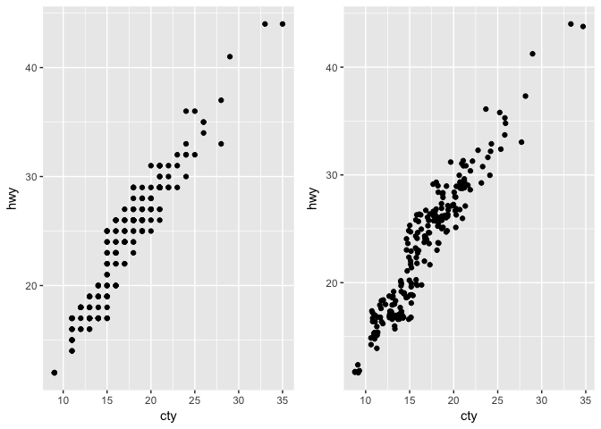

```r
# original
p1 <- ggplot(data = mpg, mapping = aes(x = cty, y = hwy)) +
  geom_point()
# change geom to jitter
p2 <- ggplot(data = mpg, mapping = aes(x = cty, y = hwy)) +
  geom_point(position = "jitter")
  # or geom_jitter()
grid.arrange(p1, p2, ncol = 2)
```

2. What parameters to geom_jitter() control the amount of jittering?

Width and height parameters control the amount of jittering.

3. Compare and contrast geom_jitter() with geom_count().

`geom_count()` maps observation counts to point area. Instead of adding jitter to reduce overplotting, `geom_count()` increases the size of points with multiple observations. We can compare a plot using `geom_count()` on the left and `geom_jitter()` on the right.

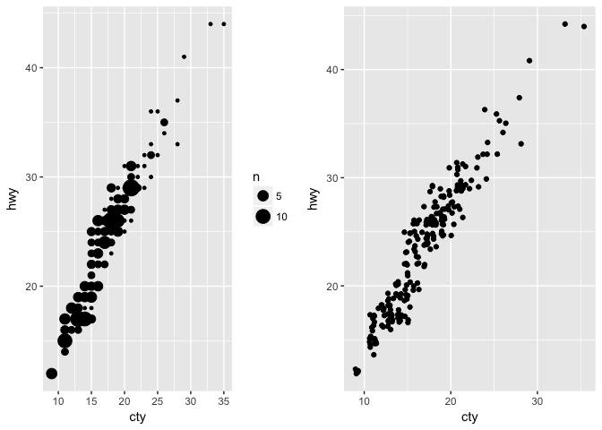

```r
p1 <- ggplot(data = mpg, mapping = aes(x = cty, y = hwy)) +
  geom_count()
p2 <- ggplot(data = mpg, mapping = aes(x = cty, y = hwy)) +
  geom_jitter()
grid.arrange(p1, p2, ncol = 2)
```

4. What’s the default position adjustment for geom_boxplot()? Create a visualisation of the mpg dataset that demonstrates it.

The default position adjustment is “dodge”. This prevents the boxplot for each level from being plotted on top of each other. However even changing it to “identity” gave the same default result. Other positions throw an error.

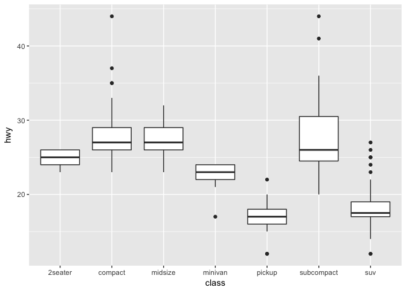

```r
ggplot(data = mpg, aes(x= class, y = hwy)) +
    geom_boxplot(position = "identity")
```

## 3.9.1 Coordinate Systems Exercises

1. Turn a stacked bar chart into a pie chart using coord_polar().

The plots on the right are pie charts taken from a stacked bar plot on the left using `coord_polar()` and setting `theta = "y"`. Neither are very effective visualizations though!

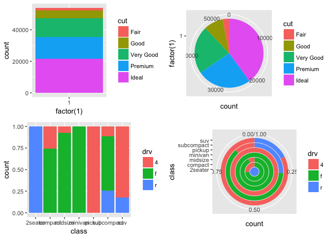

```r
p1 <- ggplot(diamonds, aes(x = factor(1), fill = cut)) +
  geom_bar()
p2 <- ggplot(diamonds, aes(x = factor(1), fill = cut)) +
  geom_bar(width = 1) +
  coord_polar(theta = "y")
p3 <- ggplot(data = mpg) +
    geom_bar(mapping = aes(x = class, fill = drv), position = "fill")
p4 <- ggplot(data = mpg) +
    geom_bar(mapping = aes(x = class, fill = drv), position = "fill") +
    coord_polar(theta = "y")
grid.arrange(p1, p2, p3, p4, ncol = 2)
```

2. What does labs() do? Read the documentation.

`labs()` lets you modify axis, legend and plot labels. For examples see below.

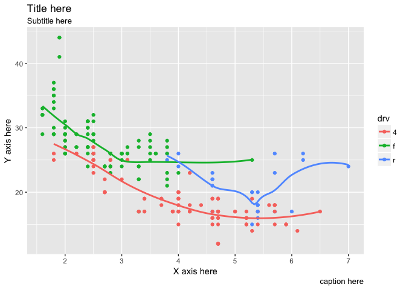

```r
ggplot(data = mpg, mapping = aes(x = displ, y = hwy, color = drv)) +
  geom_point() +
  geom_smooth(se = FALSE) +
    labs(title = "Title here",
         subtitle = "Subtitle here",
         x = "X axis here",
         y = "Y axis here",
         caption = "caption here")
```

3. What’s the difference between coord_quickmap() and coord_map()?

According to the docs, compared to `coord_map()`, `coord_quickmap()` is a quicker approximation that preserves straight lines best for smaller areas closer to the equator. Hadley notes that quickmap sets the aspect ratio correctly for maps. Here’s an example:

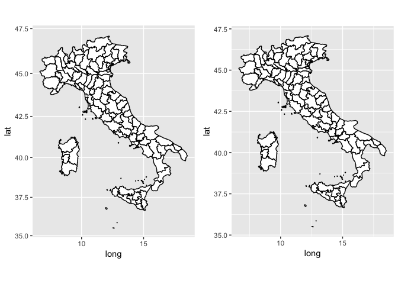

```r
italy <- map_data("italy")
itamap <- ggplot(italy, aes(x = long, y = lat, group = group)) +
  geom_polygon(fill = "white", colour = "black")

p1 <- itamap + coord_map()
p2 <- itamap + coord_quickmap()
grid.arrange(p1, p2, ncol = 2)
```

4. What does the plot below tell you about the relationship between city and highway mpg? Why is coord_fixed() important? What does geom_abline() do?

The plot suggests that the discrepancy between city and highway mpg increases for higher mpg. `geom_abline()` represents an identity line that would show perfect correspondence. `coord_fixed()` helps maintain the aspect ratio.

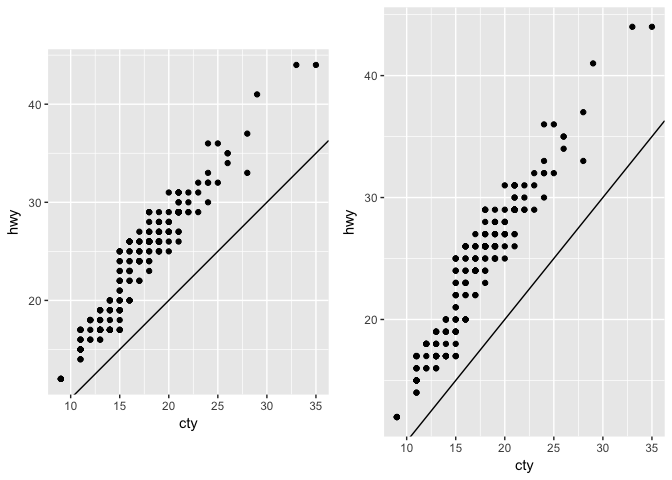

```r
# original
p1 <- ggplot(data = mpg, mapping = aes(x = cty, y = hwy)) +
  geom_point() +
  geom_abline() +
  coord_fixed()
# without coord_fixed()
p2 <- ggplot(data = mpg, mapping = aes(x = cty, y = hwy)) +
  geom_point() +
  geom_abline()
grid.arrange(p1, p2, ncol = 2)
```